# Rak piersi w Polsce

Konrad Czechowski, Bartosz Piotrowski, Jakub Tyrek

## Płeć i wiek jako czynniki ryzyka

Rak piersi kojarzy się z kobięcą chorobą, czy rzeczywiście tak jest? Na wykresie widzimy średnią liczbę roczną zachorowań wśród kobiet i mężczyzn w latach 2010 - 2012. Poniżej możemy zobaczyć częstość zachorowań w zależności od płci.

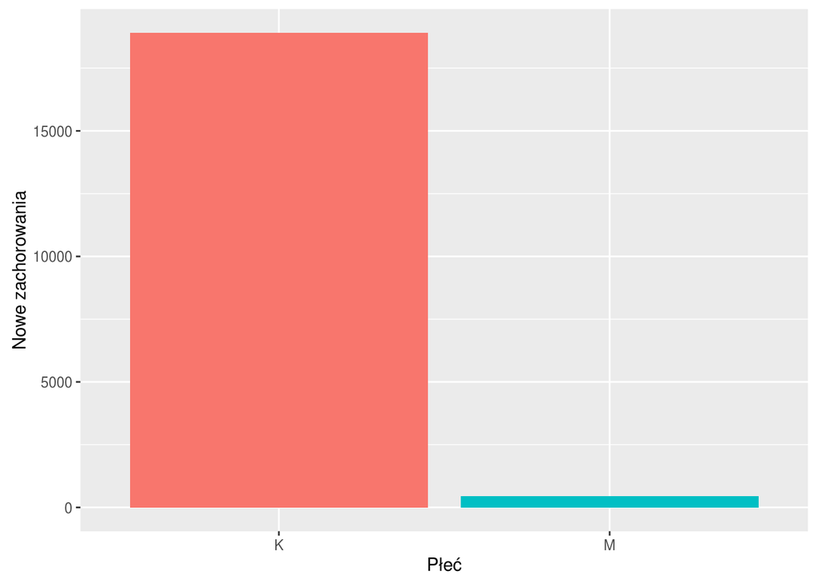

```
##   Płeć Nowe zachorowania Populacja Częstość zachorowań
## 1    K        18915.6667  19847159        9.530667e-04
## 2    M          456.6667  18607417        2.454218e-05
```

Wykres pokazuje nam o przytłaczającą dominację kobiet wśród zachorowań. Natomiast tabela mówi nam, że mężczyźni chorują 40 razy rzadziej.

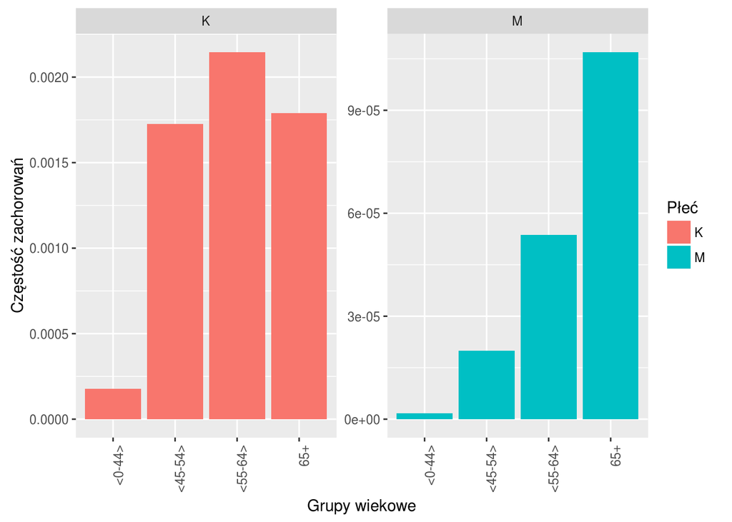

## Mapa zachorowalności

Poniżej prezentujemy mapę Polski podzieloną na powiaty. Na obszarach pokolorowanych na biało stopień zachorowalności na raka piersi jest równy średniej zachorowalności dla całego kraju, kolor czerwony oznacza zachorowalność powyżej średniej, natomias zielony - poniżej.

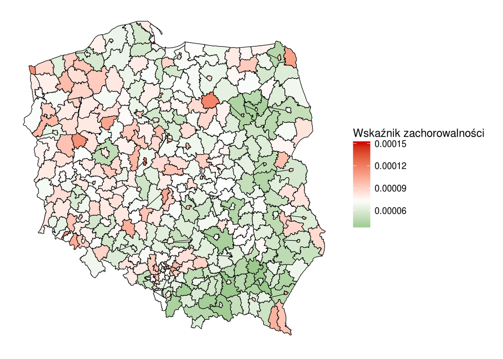

Możemy zauważyć następującą tendencję: powiaty południowo-wschodnie mają niską zachorowalność, natomiast powiaty północno-zachodnie - wysoką. Jednak z mapy ciężko odczytać powiaty o najwyższej i najniższej zachorowalności.

Powiaty z najniższą zachorowalnością - kolumna prop to stosunek średniej liczby nowych zachorowań do liczby ludności w powiecie, prop_odw to odwrotność prop.

```
##         powiat         prop prop_odw
## 1   rzeszowski 3.567803e-05 28028.45
## 2 kolbuszowski 3.606569e-05 27727.19
## 3    tarnowski 3.630900e-05 27541.38
## 4  nowosądecki 3.880915e-05 25767.12
## 5    wadowicki 3.886309e-05 25731.35
```

Powiaty z najwyższą zachorowalnością.

```
##          powiat         prop prop_odw
## 1         Sopot 0.0001507608 6633.025
## 2         Konin 0.0001194217 8373.687
## 3      nidzicki 0.0001179837 8475.750
## 4   Świnoujście 0.0001144967 8733.878
## 5 międzychodzki 0.0001136110 8801.966
```

## Urbanizacja

Jednym z czynników wartych rozważenia w predykcji jest urbanizacja regionu, na poniższym wykresie widać, że jest ona mocno powiązana ze współczynnikiem zachorowalności. (Dane za [1].)

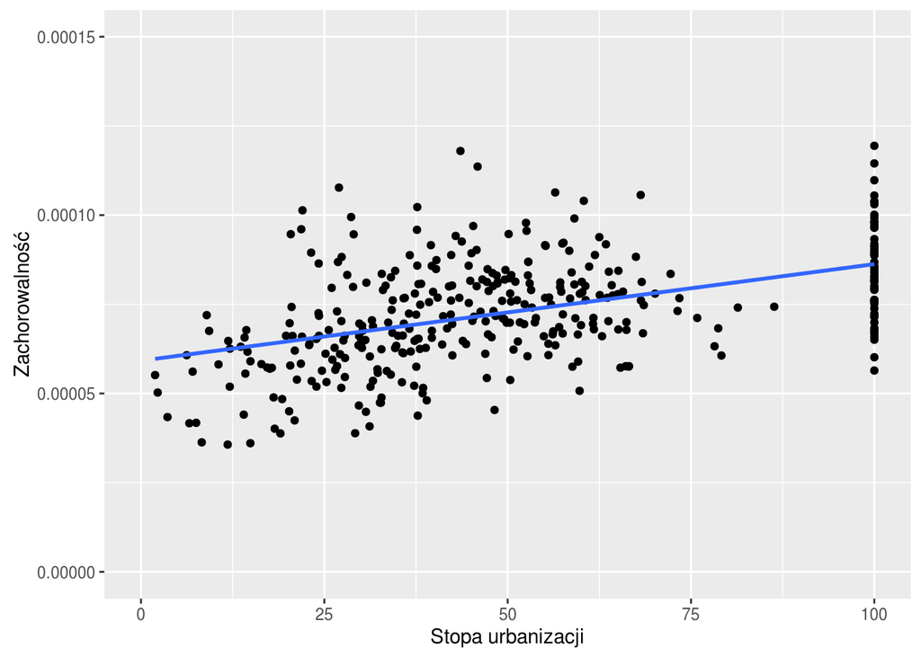

Sprawdźmy istotość i siłę korelacji

```r
cor.test(pow_data$stopa_urbanizacji, pow_data$prop, use ='complete', method='pearson')
```

```
##
##  Pearson's product-moment correlation
##
## data:  pow_data$stopa_urbanizacji and pow_data$prop
## t = 10.701, df = 372, p-value < 2.2e-16
## alternative hypothesis: true correlation is not equal to 0
## 95 percent confidence interval:
##  0.4035997 0.5590528
## sample estimates:
##       cor
## 0.4851502
```

Na wszelki wypadek potwierdźmy zależność testem nieparametrycznym.

```r
cor.test(pow_data$stopa_urbanizacji, pow_data$prop, use ='complete', method='kendall')
```

```
##
##  Kendall's rank correlation tau
##
## data:  pow_data$stopa_urbanizacji and pow_data$prop
## z = 10.006, p-value < 2.2e-16
## alternative hypothesis: true tau is not equal to 0
## sample estimates:
##       tau
## 0.3509021
```

P-value nie pozostawia wątpliwości co do istotności zależności między zmiennymi.

### Źródła:

[1] http://www.polskawliczbach.pl/Powiaty